# Construction des indices de prix de l'INSEE et de Crédit Logement

```python
import pandas as pd
import numpy as np
import sys
import os

# --- 1. Chargement des données CL ---
try:

    base_path = r"N:\uflumth\indicateur_marche\univers_elementaire\TI\bdd_univ_elem_zone_insee"

    prix_m2_univ_elem_complet_CITY = pd.read_csv(os.path.join(base_path, "prix_m2_univ_elem_complet_CITY.csv"))
    prix_m2_univ_elem_complet_DEPT = pd.read_csv(os.path.join(base_path, "prix_m2_univ_elem_complet_DEPT.csv"))
    prix_m2_univ_elem_complet_REGION = pd.read_csv(os.path.join(base_path, "prix_m2_univ_elem_complet_REGION.csv"))
    prix_m2_univ_elem_complet_PROVINCE = pd.read_csv(os.path.join(base_path, "prix_m2_univ_elem_complet_PROVINCE.csv"))

    dfs_to_concat = [
        prix_m2_univ_elem_complet_CITY,
        prix_m2_univ_elem_complet_DEPT,
        prix_m2_univ_elem_complet_REGION,
        prix_m2_univ_elem_complet_PROVINCE
    ]

    df_final = pd.concat(dfs_to_concat, ignore_index=True)

except FileNotFoundError as e:
    print(f"Erreur de lecture de fichier CL : {e}")
    sys.exit(1)

# Nettoyage df_final
df_final = df_final[df_final['DIC_NAME'] != "prix_m2_3m"]
df_final = df_final.drop(columns=["TYPE_MAILLE","TAUX_INFL_12M","TAUX_INFL_3M", "DIC_NAME"], errors='ignore')

# --- 2. Calcul de l'indice CL (Base 2020) ---
df_final["Periode"] = pd.to_datetime(df_final["Periode"]) # Conversion sûre
mask_2020 = df_final["Periode"].dt.year == 2020

if not df_final.loc[mask_2020].empty:
    # Pivot par type de bien et zone géograhique
    pivot_2020_CL = df_final.loc[mask_2020].groupby(["CD_TYPE_BIEN","VAL_MAILLE_GEO"])["prix_mm_value"].mean()

    # Application du pivot (Mapping multi-index)
    df_final["Indice de prix (CL)"] = (
        (df_final["prix_mm_value"] /
         df_final.set_index(["CD_TYPE_BIEN","VAL_MAILLE_GEO"]).index.map(pivot_2020_CL)
        ) * 100
    ).round(2)
else:
    print("Attention: Aucune donnée CL trouvée pour 2020")
    df_final["Indice de prix (CL)"] = np.nan

# --- 3. Chargement et Préparation des données INSEE ---
types_biens = ['APT', 'MAI']
perimetre_insee = ['92', '93', '94', '95', '91','75', '78', '77', "MARSEILLE", "LYON", "LILLE",'NORD-PAS-DE-CALAIS','PACA','RHONE-ALPES','PROVINCE','AUVERGNE','IDF']
insee_path = r"N:\uflumth\indicateur_marche\univers_elementaire\TI\table_rapport (2025)"
insee_to_concat = []

for perimetre in perimetre_insee:
    for type_b in types_biens:
        try:
            file_p = os.path.join(insee_path, f"valeurs_trimestrielles_{perimetre}_{type_b}.csv")
            valeurs_trimestrielles = pd.read_csv(file_p, sep=';')

            # Nettoyage structurel (slicing des 4 premières lignes inutiles)
            valeurs_trimestrielles = valeurs_trimestrielles[3:].copy()

            # Renommage dynamique de la colonne indice (souvent en position 1)
            col_indice = valeurs_trimestrielles.columns[1]
            valeurs_trimestrielles = valeurs_trimestrielles.rename(columns={col_indice: 'Indice de prix (INSEE)'})

            # Conversion numérique forcée (les erreurs deviennent NaN)
            valeurs_trimestrielles['Indice de prix (INSEE)'] = pd.to_numeric(
                valeurs_trimestrielles['Indice de prix (INSEE)'], errors='coerce'
            )

            # Parsing de la date (Ex: "2015-T1")
            valeurs_trimestrielles['Year'] = valeurs_trimestrielles['Libellé'].apply(lambda x: int(str(x).split('-')[0]))
            valeurs_trimestrielles['Quarter'] = valeurs_trimestrielles['Libellé'].apply(lambda x: int(str(x).split('T')[-1]))

            # Création chaîne propre YYYYQx
            valeurs_trimestrielles["Date code"] = (
                valeurs_trimestrielles['Year'].astype(str) + 'Q' + valeurs_trimestrielles["Quarter"].astype(str)
            )

            # Conversion en PeriodIndex
            valeurs_trimestrielles["Periode"] = pd.PeriodIndex(valeurs_trimestrielles["Date code"], freq="Q").to_timestamp()

            valeurs_trimestrielles["VAL_MAILLE_GEO"] = perimetre
            valeurs_trimestrielles["CD_TYPE_BIEN"] = type_b

            # On garde uniquement les colonnes utiles
            keep_cols = ["VAL_MAILLE_GEO", "CD_TYPE_BIEN", "Periode", "Indice de prix (INSEE)"]
            insee_to_concat.append(valeurs_trimestrielles[keep_cols])

        except Exception as e:
            # print(f"Info: Pas de fichier ou erreur pour {perimetre}_{type_b}")
            continue

if insee_to_concat:
    insee_final = pd.concat(insee_to_concat, ignore_index=True)

    # Harmonisation des noms de régions
    remplacement_regions = {
        "RHONE-ALPES": "RHÔNE-ALPES",
        "PACA": "PROVENCE-ALPES-CÔTE D'AZUR",
        "IDF": "ÎLE-DE-FRANCE"
    }
    insee_final["VAL_MAILLE_GEO"] = insee_final["VAL_MAILLE_GEO"].replace(remplacement_regions)
else:
    print("Erreur critique: Aucun fichier INSEE chargé.")
    sys.exit(1)

# --- 4. Calcul de l'indice INSEE (Base 2020) ---
insee_final["Periode"] = pd.to_datetime(insee_final["Periode"])
mask_2020_insee = insee_final["Periode"].dt.year == 2020

if not insee_final.loc[mask_2020_insee].empty:
    pivot_2020_insee = insee_final.loc[mask_2020_insee].groupby(["CD_TYPE_BIEN","VAL_MAILLE_GEO"])["Indice de prix (INSEE)"].mean()

    insee_final["Indice de prix (INSEE) - Base 2020"] = (
        (insee_final["Indice de prix (INSEE)"] /
         insee_final.set_index(["CD_TYPE_BIEN","VAL_MAILLE_GEO"]).index.map(pivot_2020_insee)
        ) * 100
    ).round(2)
else:
    print("Attention: Données INSEE 2020 manquantes.")

# --- 5. Nettoyage et Création des Clés de Fusion ---
for df in (df_final, insee_final):
    df["VAL_MAILLE_GEO"] = df["VAL_MAILLE_GEO"].astype(str).str.strip().str.upper()
    df["CD_TYPE_BIEN"] = df["CD_TYPE_BIEN"].astype(str).str.strip().str.upper()

# Création de la clé string ROBUSTE "YYYYQx" (Ex: "2025Q2")
df_final['Periode_Key'] = df_final["Periode"].dt.to_period('Q').astype(str)
insee_final['Periode_Key'] = insee_final["Periode"].dt.to_period('Q').astype(str)



# --- 6. Fusion (Merge) ---
merge = pd.merge(
    df_final,
    insee_final.drop(columns=['Periode']), # On enlève la date Timestamp INSEE pour éviter doublon
    how="inner",
    left_on=["VAL_MAILLE_GEO", "CD_TYPE_BIEN", "Periode_Key"],
    right_on=["VAL_MAILLE_GEO", "CD_TYPE_BIEN", "Periode_Key"]
)

# --- 7. Nettoyage Final et Conversion Date ---

# Renommer la clé de fusion pour la clarté
merge = merge.rename(columns={'Periode_Key': 'Periode_Trimestre_Str'})
merge = merge[merge['Periode_Trimestre_Str'].str.match(r'^\d{4}Q\d$', na=False)]

# Reconstruction de l'index temporel propre
merge["Periode"] = pd.PeriodIndex(merge['Periode_Trimestre_Str'], freq='Q').to_timestamp(how="end")
temp_period = pd.PeriodIndex(merge['Periode_Trimestre_Str'],freq='Q').to_timestamp(how='end')
merge["Periode"] = temp_period.normalize().map(lambda x: x.replace(day=1))

merge = merge.drop(columns=['prix_mm_value', 'Periode_Trimestre_Str', 'Periode_Merge'], errors='ignore')
merge = merge.loc[:, ~merge.columns.duplicated()]


# Tri final
merge = merge.sort_values(["VAL_MAILLE_GEO", "CD_TYPE_BIEN", "Periode"])

print(f"\nFusion réussie ! {len(merge)} lignes prêtes pour l'analyse.")
merge = merge[~merge["Indice de prix (INSEE) - Base 2020"].isna()]
merge.head()
```

```
Fusion réussie ! 1261 lignes prêtes pour l'analyse.
```

|  | Periode | NB_BIENS | nb_univers | VAL_MAILLE_GEO | CD_TYPE_BIEN | Indice de prix (CL) | Indice de prix (INSEE) | Indice de prix (INSEE) - Base 2020 |
| --- | --- | --- | --- | --- | --- | --- | --- | --- |
| 126 | 2015-03-01 | 24 | 6 | 75 | APT | 75.73 | 99.5 | 74.12 |
| 127 | 2015-06-01 | 42 | 6 | 75 | APT | 75.57 | 99.3 | 73.97 |
| 128 | 2015-09-01 | 60 | 6 | 75 | APT | 75.76 | 100.8 | 75.08 |
| 129 | 2015-12-01 | 72 | 6 | 75 | APT | 75.83 | 100.5 | 74.86 |
| 130 | 2016-03-01 | 71 | 6 | 75 | APT | 75.94 | 100.8 | 75.08 |

On se retrouve avec un dataframe contenant pour l'ensemble des périmètres étudiés, pour chaque période, l'indice des prix de Crédit Logement et et de l'INSEE en base 2020.

On remarquera des résultats assez proches de ces indices, on va donc devoir les comparer statistiquement pour plus de certitude

# Comparaison par mesure d'écart par période

Pour commencer l'analyse, on va venir mesurer l'écart de l'indice Crédit Logement avec celui de l'INSEE à chaque trimestre pour chaque zone géographique et type de logement.

```python
INSEE_COL = "Indice de prix (INSEE) - Base 2020"
CL_COL = "Indice de prix (CL)"

merge['Dif'] = merge["Indice de prix (CL)"] - merge['Indice de prix (INSEE) - Base 2020']
# 1. Calcul de la Corrélation
def calculate_correlation_value(df):
    """Calcule la corrélation de Pearson """
    return df[CL_COL].corr(df[INSEE_COL])

correlation_mat = (
    merge.groupby(["VAL_MAILLE_GEO", "CD_TYPE_BIEN"])
    .apply(calculate_correlation_value)
    .rename("Corrélation")
    .reset_index()
)

# 2. Stats (Ecarts)
ecarts_stats = (
    merge.groupby(["VAL_MAILLE_GEO", "CD_TYPE_BIEN"])[["Dif"]]
    .agg(
        Ecart_Moyen=("Dif", "mean"),
        Ecart_type=("Dif", "std"),
        Ecart_min=("Dif", "min"),
        Ecart_max=("Dif", "max")
    )
    .reset_index()
)

# 3. RMSE
def rmse(series):
    return np.sqrt(np.mean(series**2))

rmse_results = (
    merge.groupby(["VAL_MAILLE_GEO", "CD_TYPE_BIEN"])[["Dif"]]
    .agg(RMSE=("Dif", rmse))
    .reset_index()
)

# 4. Fusion finale
comparaison = (
    ecarts_stats
    .merge(rmse_results, on=["VAL_MAILLE_GEO", "CD_TYPE_BIEN"])
    .merge(correlation_mat, on=["VAL_MAILLE_GEO", "CD_TYPE_BIEN"])
)

print("\n--- Résultat de la Comparaison Statistique ---")
print(90*"=")
print(comparaison.describe())
comparaison
```

```
--- Résultat de la Comparaison Statistique ---
==========================================================================================
       Ecart_Moyen  Ecart_type  Ecart_min  Ecart_max       RMSE  Corrélation
count    30.000000   30.000000  30.000000  30.000000  30.000000    30.000000
mean      1.639718    2.764294  -3.254000   7.342667   3.398845     0.962181
std       1.441919    0.735949   2.122769   1.752000   1.074938     0.019464
min      -2.089286    1.609729 -10.840000   3.610000   1.776801     0.906154
25%       0.888036    2.300989  -3.685000   6.325000   2.628914     0.954538
50%       1.491786    2.597384  -2.755000   7.285000   3.218422     0.966497
75%       2.133810    3.016230  -2.167500   8.322500   3.638721     0.975715
max       5.295952    5.505057  -0.560000  11.330000   6.778598     0.987846
```

|  | VAL_MAILLE_GEO | CD_TYPE_BIEN | Ecart_Moyen | Ecart_type | Ecart_min | Ecart_max | RMSE | Corrélation |
| --- | --- | --- | --- | --- | --- | --- | --- | --- |
| 0 | 75 | APT | 1.965116 | 2.628621 | -1.87 | 7.96 | 3.257398 | 0.965903 |
| 1 | 77 | APT | 1.701667 | 2.956510 | -2.19 | 8.38 | 3.380607 | 0.906154 |
| 2 | 77 | MAI | 0.549286 | 2.972455 | -3.71 | 7.55 | 2.987781 | 0.940471 |
| 3 | 78 | APT | 1.464762 | 2.010122 | -1.30 | 6.31 | 2.467775 | 0.960680 |
| 4 | 78 | MAI | 0.922857 | 2.262102 | -2.75 | 6.18 | 2.418043 | 0.960260 |
| 5 | 91 | APT | 1.286190 | 2.283664 | -2.25 | 6.87 | 2.597160 | 0.953007 |
| 6 | 91 | MAI | 1.480476 | 2.232567 | -1.58 | 7.29 | 2.656594 | 0.960993 |
| 7 | 92 | APT | 1.840238 | 2.187366 | -1.49 | 7.21 | 2.838508 | 0.971743 |
| 8 | 92 | MAI | -2.089286 | 2.425665 | -6.69 | 3.61 | 3.179446 | 0.966360 |
| 9 | 93 | APT | 3.750476 | 3.119756 | -0.87 | 10.00 | 4.854608 | 0.949185 |
| 10 | 93 | MAI | -1.033571 | 2.985460 | -6.64 | 4.76 | 3.125544 | 0.969054 |
| 11 | 94 | APT | 1.979524 | 2.212860 | -1.15 | 7.06 | 2.949352 | 0.969533 |
| 12 | 94 | MAI | 1.517619 | 3.000279 | -3.06 | 7.87 | 3.330242 | 0.974090 |
| 13 | 95 | APT | 1.790952 | 3.082132 | -2.47 | 8.24 | 3.532827 | 0.926093 |
| 14 | 95 | MAI | 0.897857 | 2.508102 | -3.61 | 7.38 | 2.635706 | 0.966634 |
| 15 | AUVERGNE | APT | 5.295952 | 4.282397 | -3.35 | 11.33 | 6.778598 | 0.933577 |
| 16 | AUVERGNE | MAI | 0.985238 | 5.505057 | -10.84 | 8.87 | 5.527638 | 0.931495 |
| 17 | LILLE | MAI | 0.749762 | 3.640301 | -6.30 | 7.89 | 3.674019 | 0.976197 |
| 18 | LYON | APT | 3.896429 | 3.191873 | -2.16 | 10.52 | 5.012747 | 0.974271 |
| 19 | MARSEILLE | APT | 0.706667 | 2.429130 | -4.71 | 6.18 | 2.501911 | 0.983767 |
| 20 | NORD-PAS-DE-CALAIS | APT | 1.445238 | 3.023402 | -4.54 | 6.57 | 3.318438 | 0.985100 |
| 21 | NORD-PAS-DE-CALAIS | MAI | 3.028571 | 2.566146 | -2.38 | 8.35 | 3.949755 | 0.959130 |
| 22 | PROVENCE-ALPES-CÔTE D'AZUR | APT | 0.792143 | 1.609729 | -2.57 | 4.75 | 1.776801 | 0.987846 |
| 23 | PROVENCE-ALPES-CÔTE D'AZUR | MAI | 0.884762 | 2.352964 | -3.60 | 6.41 | 2.487453 | 0.980346 |
| 24 | PROVINCE | APT | 2.185238 | 2.495916 | -2.76 | 5.44 | 3.294926 | 0.980650 |
| 25 | PROVINCE | MAI | 1.503095 | 2.180176 | -3.45 | 5.13 | 2.626651 | 0.982718 |
| 26 | RHÔNE-ALPES | APT | 3.103810 | 3.021547 | -2.21 | 9.15 | 4.306507 | 0.966770 |
| 27 | RHÔNE-ALPES | MAI | 2.255952 | 2.715536 | -3.77 | 7.28 | 3.505408 | 0.977185 |
| 28 | ÎLE-DE-FRANCE | APT | 3.724048 | 2.663311 | -0.56 | 9.37 | 4.559920 | 0.944090 |
| 29 | ÎLE-DE-FRANCE | MAI | 0.610476 | 2.383688 | -2.79 | 6.37 | 2.432975 | 0.962133 |

Les résultats semblent confirmer la bonne adéquation de l'indice de Crédit logement avec l'indice de l'INSEE: toutes les statistiques sont relativement faibles pour chaque périmètre (les indices étant exprimés en base 100). L'indicateur phare est le RMSE

### Interprétation par Indicateur

#### **1. Écart Moyen**

- **Moyenne : 1,62** → Les deux indices sont très proches, avec une légère surévaluation en moyenne.
- **Amplitude : -2,08 à 5,29** → Quelques segments présentent des écarts négatifs ou positifs, mais globalement faibles.

#### **3. Écart Min / Max**

- **Extrêmes : -10,84 et 11,33** → Cas isolés avec écarts importants.
- **→ Action :** Vérifier si ces outliers sont liés à des anomalies.

#### **4. RMSE**

- **Moyenne : 3,39** → Erreur moyenne faible, ce qui est satisfaisant pour des indices en base 100.

#### **5. Corrélation**

- **Très élevée (≈ 0,962)** → Forte cohérence entre les deux indices.
- **→ Conclusion :** La tendance générale est bien capturée, les écarts viennent de détails locaux.

### Synthèse

- **Points forts :** Corrélation très élevée, écarts moyens faibles → bonne fiabilité globale.
- **Points faibles :** Quelques segments avec outliers

L'objectif de la prochaine étape est de déterminer, d'un point de vue statistique :

- **Si cet écart est significatif** (c'est-à-dire non dû au hasard),
- **Si cet écart est stationnaire dans le temps**, autrement dit s'il suit une tendance stable ou évolutive.

Ces tests permettront de mieux comprendre la nature et la persistance de la divergence entre les deux indices.

```python
from statsmodels.tsa.stattools import adfuller
from scipy import stats
def test_t_significativite(group):
    ecarts_series = group["Dif"].dropna()
    if len(ecarts_series) < 15:
        return pd.Series({
            "T_stat":np.nan,
            "p_value": np.nan,
            "Significatif (p_value < 0.05)": "Données insuffisantes"
        })
    t_test,p_value = stats.ttest_1samp(
        ecarts_series,
        popmean = 0,
        alternative= 'two-sided')
    return pd.Series({
            "Ecart moyen observé": round(ecarts_series.mean(),2),
            "T_stat": round(t_test,3),
            "p_value": round(p_value,4),
            "Significatif (p_value < 0.05)": p_value < 0.05
        })
test_t_results = merge.groupby(["VAL_MAILLE_GEO","CD_TYPE_BIEN"]).apply(test_t_significativite)
print("--Résultats du Test t--")
print(test_t_results)

def test_adf_stationnarite(group):
    ecart_series = group['Dif'].dropna()


    if len(ecart_series) < 20:
        return pd.Series({'Stationnaire (ADF)': np.nan})


    adf_result = adfuller(ecart_series)
    p_value = adf_result[1]

    return pd.Series({
        'Stationnaire (ADF)': p_value < 0.05
    })

adf_results = merge.groupby(["VAL_MAILLE_GEO", "CD_TYPE_BIEN"]).apply(test_adf_stationnarite).reset_index()
print("--Résultats du Test ADF--")
print(adf_results)
```

```
--Résultats du Test t--
                                         Ecart moyen observé  T_stat  p_value  \
VAL_MAILLE_GEO             CD_TYPE_BIEN
75                         APT                          1.97   4.902   0.0000
77                         APT                          1.70   3.730   0.0006
                           MAI                          0.55   1.198   0.2380
78                         APT                          1.46   4.722   0.0000
                           MAI                          0.92   2.644   0.0116
91                         APT                          1.29   3.650   0.0007
                           MAI                          1.48   4.298   0.0001
92                         APT                          1.84   5.452   0.0000
                           MAI                         -2.09  -5.582   0.0000
93                         APT                          3.75   7.791   0.0000
                           MAI                         -1.03  -2.244   0.0303
94                         APT                          1.98   5.797   0.0000
                           MAI                          1.52   3.278   0.0021
95                         APT                          1.79   3.766   0.0005
                           MAI                          0.90   2.320   0.0254
AUVERGNE                   APT                          5.30   8.015   0.0000
                           MAI                          0.99   1.160   0.2528
LILLE                      MAI                          0.75   1.335   0.1893
LYON                       APT                          3.90   7.911   0.0000
MARSEILLE                  APT                          0.71   1.885   0.0665
NORD-PAS-DE-CALAIS         APT                          1.45   3.098   0.0035
                           MAI                          3.03   7.649   0.0000
PROVENCE-ALPES-CÔTE D'AZUR APT                          0.79   3.189   0.0027
                           MAI                          0.88   2.437   0.0192
PROVINCE                   APT                          2.19   5.674   0.0000
                           MAI                          1.50   4.468   0.0001
RHÔNE-ALPES                APT                          3.10   6.657   0.0000
                           MAI                          2.26   5.384   0.0000
ÎLE-DE-FRANCE              APT                          3.72   9.062   0.0000
                           MAI                          0.61   1.660   0.1046

                                         Significatif (p_value < 0.05)
VAL_MAILLE_GEO             CD_TYPE_BIEN
75                         APT                                    True
77                         APT                                    True
                           MAI                                   False
78                         APT                                    True
```

[output cut: 43 more lines]

```
15                    AUVERGNE          APT               False
16                    AUVERGNE          MAI               False
17                       LILLE          MAI               False
18                        LYON          APT               False
19                   MARSEILLE          APT               False
20          NORD-PAS-DE-CALAIS          APT               False
21          NORD-PAS-DE-CALAIS          MAI                True
22  PROVENCE-ALPES-CÔTE D'AZUR          APT               False
23  PROVENCE-ALPES-CÔTE D'AZUR          MAI               False
24                    PROVINCE          APT               False
25                    PROVINCE          MAI               False
26                 RHÔNE-ALPES          APT               False
27                 RHÔNE-ALPES          MAI               False
28               ÎLE-DE-FRANCE          APT               False
29               ÎLE-DE-FRANCE          MAI               False
```

### 1. Test t de Student – Significativité de l’écart moyen

**Objectif :** Vérifier si l’écart moyen entre les deux indices est statistiquement différent de zéro.

> **Conclusion :** Les écarts sont faibles en valeur absolue mais **statistiquement significatifs dans la majorité des cas** (83.3% de True). Cela confirme l'existence d'un biais structurel qui n'est pas dû au hasard.

### 2. Test ADF – Stationnarité des écarts dans le temps

**Objectif :** Vérifier si la série des écarts est stationnaire ou si elle dérive.

- **Hypothèses :**
  - $H_0$ : La série a une racine unitaire ($\gamma = 0$) $\rightarrow$ **NON STATIONNAIRE** (Dérive).
  - $H_1$ : La série n'a pas de racine unitaire ($\gamma < 0$) $\rightarrow$ **STATIONNAIRE** (Stable).
- **Statistique de test :** Basée sur le modèle de régression suivant : $$\Delta y_t = \alpha + \beta t + \gamma y_{t-1} + \epsilon_t$$
- **Résultats :**
  - **Majorité des segments (90%) : NON STATIONNAIRES** ($p > 0.05$). L'hypothèse nulle n'est pas rejetée. L’écart évolue et dérive dans le temps.

> **Conclusion :** Pour la majorité des zones, **l’écart n’est pas stable**. Il varie avec le temps, confirmant la divergence observée visuellement sur la période récente (2022-2023).

> **Conséquence :** Un correctif fixe (moyenne) serait faux à long terme. Il est nécessaire d'utiliser un modèle de correction dynamique.

## Modèle à Correction d'Erreur (ECM)

L’objectif de l'ECM est d’examiner s’il existe un mécanisme de **rappel** qui contraint les écarts entre les indices CL et INSEE à revenir vers un équilibre de long terme.

Il permet donc de prédire la variation de l'indice INSEE ($\Delta \text{INSEE}_t$) en fonction des chocs immédiats ($\Delta \text{CL}_t$) et du déséquilibre passé ($\text{Écart}_{t-1}$).

Le modèle estimé est le suivant :

> $$\Delta \text{INSEE}_t = \alpha + \beta_1 \Delta \text{CL}_t + \gamma \cdot (\text{CL}_{t-1} - \text{INSEE}_{t-1}) + \epsilon_t$$

```python
import pandas as pd
import statsmodels.api as sm

df_ecm = merge.copy()

# 1. Calculer les variations (Différences premières)
df_ecm['Delta_INSEE'] = df_ecm['Indice de prix (INSEE) - Base 2020'].diff()
df_ecm['Delta_CL'] = df_ecm['Indice de prix (CL)'].diff()

# 2. Récupérer l'écart (Residual) du trimestre précédent (t-1)
# Note : 'Dif' est (CL - INSEE), l'ECM utilise souvent (Y - aX).
df_ecm['Ecart_Lag1'] = df_ecm['Dif'].shift(1)

df_ecm = df_ecm.dropna()

# 4. Définir Y (Variable cible) et X (Explicatives)
# On veut expliquer les variations de l'INSEE par celles du CL + le rappel à l'ordre
Y = df_ecm['Delta_INSEE']
X = df_ecm[['Delta_CL', 'Ecart_Lag1']]
X = sm.add_constant(X) # Ajouter une constante

# 5. Lancer la régression
model = sm.OLS(Y, X).fit()

print(model.summary())
```

```
                            OLS Regression Results
==============================================================================
Dep. Variable:            Delta_INSEE   R-squared:                       0.793
Model:                            OLS   Adj. R-squared:                  0.792
Method:                 Least Squares   F-statistic:                     2401.
Date:              lun., 08 déc. 2025   Prob (F-statistic):               0.00
Time:                        14:10:03   Log-Likelihood:                -2375.2
No. Observations:                1260   AIC:                             4756.
Df Residuals:                    1257   BIC:                             4772.
Df Model:                           2
Covariance Type:            nonrobust
==============================================================================
                 coef    std err          t      P>|t|      [0.025      0.975]
------------------------------------------------------------------------------
const         -0.1690      0.051     -3.299      0.001      -0.269      -0.068
Delta_CL       0.8765      0.013     67.797      0.000       0.851       0.902
Ecart_Lag1     0.1038      0.015      6.950      0.000       0.074       0.133
==============================================================================
Omnibus:                       74.403   Durbin-Watson:                   2.082
Prob(Omnibus):                  0.000   Jarque-Bera (JB):              229.669
Skew:                           0.234   Prob(JB):                     1.34e-50
Kurtosis:                       5.038   Cond. No.                         4.69
==============================================================================

Notes:
[1] Standard Errors assume that the covariance matrix of the errors is correctly specified.
```

# Analyse des Résultats – Modèle à Correction d'Erreur (ECM)

[output not shown]

### Interprétation des Résultats

1. **Mécanisme de "Co-intégration" ($\gamma$) :**
   - Le coefficient $\gamma$ est **positif ** ($\approx +0.103$).
   - Puisque l'écart est défini $\text{CL} - \text{INSEE}$, un écart positif (CL est trop haut) est corrigé par une accélération de l'INSEE ($\Delta \text{INSEE}_t > 0$).
   - **Conclusion :** Cela prouve l'existence d'une **force de rappel**. A terme, les indices ne divergeront pas.
2. **Vitesse d'Ajustement :**
   - La valeur de $\gamma$ ($\mathbf{0.103}$) signifie que **$10.3\%$ du déséquilibre** est corrigé par l'indice INSEE au trimestre suivant.
   - L’écart n’est pas totalement absorbé rapidement, ce qui peut expliquer des divergences persistantes.

# Influence de la variable NB_BIENS

On dispose de la variable NB_BIENS apportant des informations sur la volumétrie de chaque périmètre à chaque période. Il peut être intéressant de vérifier si cette dernière influence l'écart observé entre nos deux indices. Pour ce faire, nous allons appliquer une regression de l'écart des indices avec cette variable.

Tout d'abord, nous allons appliquer la transformation de Cox-Box afin de rendre la distribution de la variable plus "normale"

```
Lambda optimal: 1.7632003599519
```

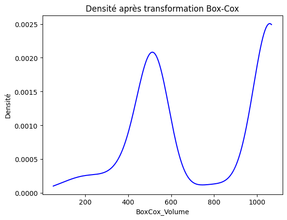

```python
import matplotlib.pyplot as plt
from scipy.stats import boxcox
merge = merge[merge["NB_BIENS"] > 0]

merge['Transf_Vol'],lambda_value = boxcox(merge['NB_BIENS'])
merge["Log_Volume"] = np.log(merge['NB_BIENS'])
print(f"Lambda optimal: {lambda_value}")

from scipy.stats import gaussian_kde
import numpy as np
import matplotlib.pyplot as plt

data = merge['Transf_Vol']

density = gaussian_kde(data)
x_vals = np.linspace(min(data), max(data), 200)

plt.plot(x_vals, density(x_vals), color='blue')
plt.title('Densité après transformation Box-Cox')
plt.xlabel('BoxCox_Volume')
plt.ylabel('Densité')
plt.show()
```

# Régression linéaire

```python
import statsmodels.api as sm
import pandas as pd
import numpy as np


analyse_volume = []

grouped = merge.groupby(["VAL_MAILLE_GEO", "CD_TYPE_BIEN"])

print("Analyse de l'impact de la Volumétrie sur l'Écart...")

for name, group in grouped:
    zone, type_bien = name


    df_reg = group.dropna(subset=['Dif', 'NB_BIENS']).copy()

    if len(df_reg) > 12:
        try:
            # 1. Transformation du volume (Box-Cox pour normaliser)
            df_reg['Transf_Vol'], lambda_val = boxcox(df_reg['NB_BIENS'])

            # 2. Définition des variables
            Y = df_reg['Dif']           # Ce qu'on veut expliquer (L'écart)
            X = df_reg[['Transf_Vol']]  # La cause potentielle
            X = sm.add_constant(X)      # Ajout de la constante

            # 3. Régression OLS
            model = sm.OLS(Y, X).fit()

            # 4. Récupération des résultats clés
            beta_volume = model.params['Transf_Vol']
            p_value = model.pvalues['Transf_Vol']
            r_squared = model.rsquared

            # 5. Interprétation automatique
            significatif = "OUI" if p_value < 0.05 else "NON"

            analyse_volume.append({
                "Zone": zone,
                "Type": type_bien,
                "Corrélation (Pearson)": df_reg['Dif'].corr(df_reg['NB_BIENS']).round(2),
                "Impact Volume (Beta)": round(beta_volume, 4),
                "P-value": round(p_value, 4),
                "Significatif à 5%": significatif,
                "R2 ": round(r_squared, 3)
            })

        except Exception as e:
            pass


df_analyse_vol = pd.DataFrame(analyse_volume)


print("\n--- Segments où le Volume explique l'Écart (Significatif) ---")
print(df_analyse_vol[df_analyse_vol["Significatif à 5%"] == "OUI"])

# Affichage global
print(df_analyse_vol)
```

```
Analyse de l'impact de la Volumétrie sur l'Écart...

--- Segments où le Volume explique l'Écart (Significatif) ---
                          Zone Type  Corrélation (Pearson)  \
0                           75  APT                  -0.21
1                           77  APT                   0.11
3                           78  APT                   0.19
5                           91  APT                   0.18
6                           91  MAI                   0.11
7                           92  APT                   0.17
8                           92  MAI                  -0.17
9                           93  APT                   0.07
10                          93  MAI                  -0.32
11                          94  APT                   0.17
12                          94  MAI                  -0.30
```

[output cut: 102 more lines]

## Analyse de l'impact de la Volumétrie ($NB\_BIENS$)

L'objectif était de vérifier si la liquidité du marché (représentée par la volumétrie de transactions, $NB\_BIENS$) est une variable explicative de la dérive de l'écart ($\text{CL} - \text{INSEE}$).

[output not shown]

### Conclusion

1. **Incohérence statistique :** La $P\text{-value}$ a indiqué une dépendance ($p < 0.05$), mais la valeur du coefficient ($\beta$) prouve que cette dépendance est **trop faible pour être significative**.
2. **Volumétrie (NB_BIENS) :** Elle est jugée **non pertinente** comme variable explicative de l'écart. L'écart est donc probablement déterminé par d'autres variables externes.

> **Conséquence:** Le modèle de correction du biais ne doit **pas** être enrichi par la variable NB_BIENS car cela n'ajouterait que du bruit et de la complexité inutile.

# Stratégie de correction du Biais par modélisation dynamique

Nous avons constaté un écart entre les deux indices dont la cause n'a pu être expliquée par la volumétrie. Cependant, nous allons tenter de le corriger.

Il n'est pas pertinent d'appliquer une simple moyenne historique de l'écart comme correctif pour chaque périmètre, car cela introduirait un biais trop important. L'analyse par le **Test ADF** a en effet montré que l'écart est **non-stationnaire** (il dérive).

À la place, nous allons modéliser cette dérive en mettant en place un **écart dynamique**.

Pour déterminer le meilleur modèle capable de prédire l'évolution future de l'écart, nous avons mis en place une compétition entre deux modèles, validée par **Cross-Validation Temporelle**.

### 1. Les Modèles Sélectionnés

Nous avons comparé deux approches de séries temporelles capables de gérer la **saisonnalité** et la **tendance** :

- **SARIMA :** Modèle paramétrique rigoureux.
- **TES (Triple Exponential Smoothing) :** Modèle par lissage qui capture le niveau, la tendance et la saisonnalité.

### 2. Processus de Validation

Le processus consiste à :

1. **Optimiser les hyperparamètres** ARIMA par minimisation de l'AIC.
2. **Entraîner les modèles** sur l'échantillon *train* (historique).
3. **Évaluer la performance** sur l'échantillon *validation*.
4. **Sélectionner** le modèle présentant le **RMSE Moyen le plus faible** et la meilleure stabilité (écart-type du RMSE).

# Modèles de Séries Temporelles

### 1. ARIMA (AutoRegressive Integrated Moving Average)

ARIMA est un modèle paramétrique qui décompose la série en trois dynamiques :

- **AR (AutoRegressive) :** Utilisation des valeurs passées ($y_{t-i}$) pour la prévision.
- **I (Integrated) :** Différenciation de la série ($d$ fois) pour la rendre stationnaire.
- **MA (Moving Average) :** Utilisation des erreurs passées ($\varepsilon_{t-i}$) pour affiner la prévision.

**Formulation générale pour un ARIMA($p, d, q$) :**

> $$\phi(B)(1-B)^d y_t = \theta(B)\varepsilon_t$$

Où :

- $y_t$ est la valeur à l'instant $t$.
- $B$ est l'opérateur de retard ($B y_t = y_{t-1}$).
- $\phi(B)$ est la partie AR (ordre $p$).
- $\theta(B)$ est la partie MA (ordre $q$).
- $d$ est l'ordre de différenciation.

## Triple Lissage Exponentiel (TES / Holt-Winters)

Le modèle TES est l'approche de lissage la plus complète. Il correspond à un Double Exponential Smoothing (Holt-Winters) avec une intégration de correction de saisonnalité. C'est un modèle qui accorde un poids plus important aux données les plus récentes.

### 1. Composantes

Le modèle estime trois composantes, chacune gérée par un coefficient de lissage distinct ($\alpha, \beta, \gamma$) :

| Composante | Rôle | Coefficient |
| --- | --- | --- |
| **Niveau ($\ell_t$)** | Capture la valeur moyenne actuelle de l'écart. | $\alpha$ (Alpha) |
| **Tendance ($b_t$)** | Capture la **dérive** de l'écart (l'accélération ou le ralentissement du biais). | $\beta$ (Beta) |
| **Saisonnalité ($s_t$)** | Capture le **cycle trimestriel** répétitif (saisonnalité). | $\gamma$ (Gamma) |

### 2. Formule du Modèle TES (Holt-Winters Additif)

Le Modèle de Triple Lissage Exponentiel (TES) est défini par les équations suivantes, où $\alpha$, $\beta$, et $\gamma$ sont les coefficients de lissage (entre 0 et 1), et $m=4$ est la période saisonnière.

Le nouveau niveau ($\ell_t$) est calculé en corrigeant l'observation $y_t$ par l'ancien facteur saisonnier, puis en lissant ce résultat avec l'ancienne projection de niveau et tendance :

$$\ell_t = \alpha (y_t - s_{t-m}) + (1-\alpha)(\ell_{t-1} + b_{t-1})$$

La nouvelle tendance ($b_t$) est calculée en lissant la variation récente du niveau ($\ell_t - \ell_{t-1}$) avec l'ancienne estimation de la tendance :

$$b_t = \beta (\ell_t - \ell_{t-1}) + (1-\beta)b_{t-1}$$

Le nouveau facteur saisonnier ($s_t$) est calculé en lissant la décomposition saisonnière actuelle ($y_t - \ell_t$) avec l'ancien facteur saisonnier :

$$s_t = \gamma (y_t - \ell_t) + (1-\gamma)s_{t-m}$$

La prévision finale est la somme des trois composantes projetées :

> $$\hat{y}_{t+h} = \ell_t + h b_t + s_{t+h-m}$$

La première étape est d'analyser la saisonnalité

```
Analyse de la Saisonnalité de l'Écart...
```

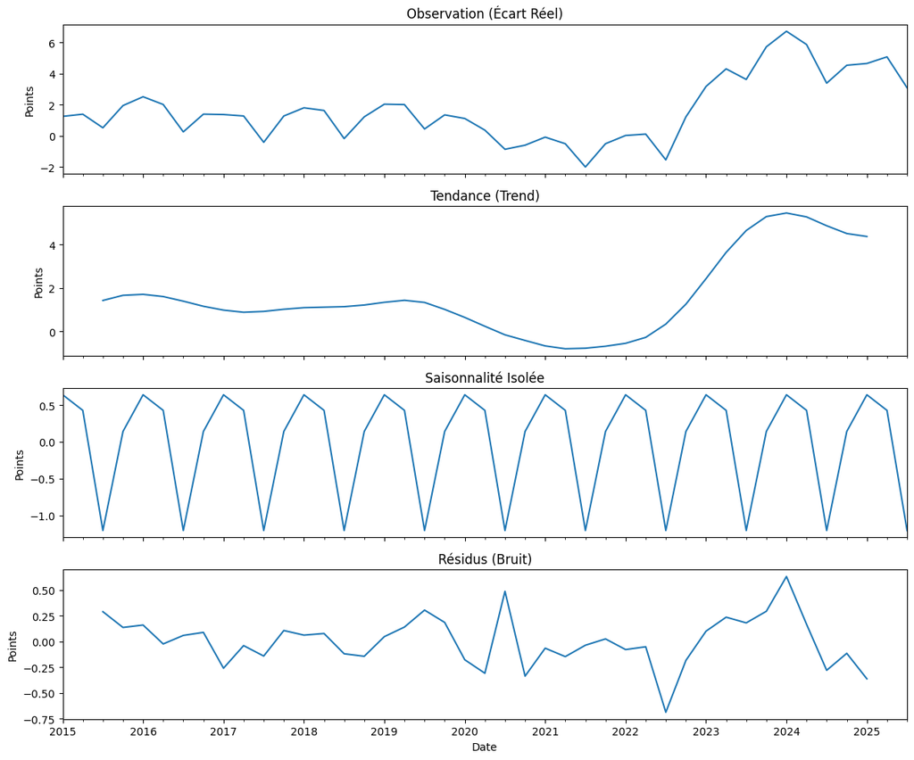

```
Amplitude de la saisonnalité : 1.8464 points
Amplitude de la tendance     : 6.2511 points
 Forte saisonnalité détectée
```

```python
from statsmodels.tsa.seasonal import seasonal_decompose
import matplotlib.pyplot as plt

# 1. PRÉPARATION DE LA SÉRIE TEMPORELLE
# On s'assure que la série est bien triée par date
df_analyse = merge.sort_values("Periode").set_index("Periode")
df_analyse['Dif'] = df_analyse['Indice de prix (CL)'] - df_analyse['Indice de prix (INSEE) - Base 2020']
ts_ecart = df_analyse.groupby('Periode')['Dif'].mean()


print("Analyse de la Saisonnalité de l'Écart...")

try:
    # decomposition (model='additive' car l'écart peut être négatif)
    res = seasonal_decompose(ts_ecart, model='additive', period=4) # period=4 pour des trimestres

    # Affichage
    fig, (ax1, ax2, ax3, ax4) = plt.subplots(4, 1, figsize=(12, 10), sharex=True)

    res.observed.plot(ax=ax1, title='Observation (Écart Réel)')
    ax1.set_ylabel('Points')

    res.trend.plot(ax=ax2, title='Tendance (Trend)')
    ax2.set_ylabel('Points')

    res.seasonal.plot(ax=ax3, title='Saisonnalité Isolée')
    ax3.set_ylabel('Points')

    res.resid.plot(ax=ax4, title='Résidus (Bruit)')
    ax4.set_ylabel('Points')

    plt.xlabel('Date')
    plt.tight_layout()
    plt.show()

    # Test rapide de la force de la saisonnalité
    seasonal_range = res.seasonal.max() - res.seasonal.min()
    trend_range = res.trend.max() - res.trend.min()

    print(f"Amplitude de la saisonnalité : {seasonal_range:.4f} points")
    print(f"Amplitude de la tendance     : {trend_range:.4f} points")

    if seasonal_range > 0.2 * trend_range: # Règle empirique
        print(" Forte saisonnalité détectée ")
    else:
        print("Pas de saisonnalité majeure détectée.")

except Exception as e:
    print(e)
```

## Compétition des modèles

```python
import pandas as pd
import numpy as np
import itertools
import warnings
import logging
from sklearn.model_selection import TimeSeriesSplit
from sklearn.metrics import mean_squared_error
from statsmodels.tsa.arima.model import ARIMA
from statsmodels.tsa.holtwinters import ExponentialSmoothing
from prophet import Prophet

# --- CONFIGURATION ---
warnings.filterwarnings("ignore")
logging.getLogger('cmdstanpy').setLevel(logging.WARNING)
logging.getLogger('prophet').setLevel(logging.WARNING)

# --- BOUCLE SUR CHAQUE SEGMENT ---
unique_segments = merge.groupby(["VAL_MAILLE_GEO", "CD_TYPE_BIEN"])

for segment_name, segment_data in unique_segments:
    print(f"\n========================================================")
    print(f"ANALYSE DU SEGMENT : {segment_name}")
    print(f"========================================================")

    # 1. PRÉPARATION DES DONNÉES
    df_analyse = segment_data.sort_values("Periode").set_index("Periode")

    if 'Dif' not in df_analyse.columns:
        df_analyse['Dif'] = df_analyse['Indice de prix (CL)'] - df_analyse['Indice de prix (INSEE) - Base 2020']

    ts_ecart = df_analyse['Dif'].dropna()
    ts_ecart.index = pd.PeriodIndex(ts_ecart.index, freq='Q')

    print(f"   Série chargée : {len(ts_ecart)} trimestres du {ts_ecart.index[0]} au {ts_ecart.index[-1]}")

    if len(ts_ecart) < 16: # Besoin de minimum 16 points pour CV 5 splits + horizon 4
        print("   ⚠️ Série trop courte pour l'analyse complète. Passage au segment suivant.")
        continue

    # ==============================================================================
    # 2. OPTIMISATION SARIMA (Grid Search AIC)
    # ==============================================================================
    print("   2. Optimisation SARIMA...")

    p = q = range(0, 3)
    d = [1]
    P = Q = range(0, 2)
    D = [0, 1]
    s = [4]

    pdq = list(itertools.product(p, d, q))
    seasonal_pdq = list(itertools.product(P, D, Q, s))

    best_aic = float("inf")
    best_order = (1, 1, 0)
    best_seasonal_order = (0, 0, 0, 4)

    train_calibration = ts_ecart.iloc[:int(len(ts_ecart)*0.75)] # Calibration sur le passé

    for param in pdq:
        for param_seasonal in seasonal_pdq:
            try:
                mod = ARIMA(train_calibration, order=param, seasonal_order=param_seasonal,
                            enforce_stationarity=False, enforce_invertibility=False)
                results = mod.fit()
                if results.aic < best_aic:
                    best_aic = results.aic
                    best_order = param
                    best_seasonal_order = param_seasonal
            except:
                continue

    print(f"      -> SARIMA Optimal : Order={best_order}, Seasonal={best_seasonal_order}")




    # ==============================================================================
    # 4. LE TOURNOI : CROSS-VALIDATION (Robustesse)
    # ==============================================================================
    print("   3. Estimation du meilleur modèle...")

    n_splits = 5
    test_horizon = 4
    tscv = TimeSeriesSplit(n_splits=n_splits, test_size=test_horizon)   ## Cross Validation de séries temporelles

    results_cv = {'SARIMA Opti': [], 'TES (Holt-Winters)': []}

    for train_index, test_index in tscv.split(ts_ecart):
        cv_train = ts_ecart.iloc[train_index]
        cv_test = ts_ecart.iloc[test_index]

        # A. SARIMA
        try:
            mod = ARIMA(cv_train, order=best_order, seasonal_order=best_seasonal_order,
                        enforce_stationarity=False, enforce_invertibility=False).fit()
            pred = mod.forecast(steps=test_horizon)
            results_cv['SARIMA Opti'].append(np.sqrt(mean_squared_error(cv_test, pred)))
        except:
            results_cv['SARIMA Opti'].append(np.nan)


        # B. TES (Holt-Winters)
        try:
            mod = ExponentialSmoothing(cv_train, trend='add', seasonal='add', seasonal_periods=4, damped_trend=True, initialization_method="estimated").fit()
            pred = mod.forecast(steps=test_horizon)
            results_cv['TES (Holt-Winters)'].append(np.sqrt(mean_squared_error(cv_test, pred)))
        except:
            results_cv['TES (Holt-Winters)'].append(np.nan)



    # ==============================================================================
    # 5. RÉSULTATS FINAUX DU SEGMENT
    # ==============================================================================
    df_results = pd.DataFrame(results_cv)
    summary = pd.DataFrame({
        'RMSE Moyen': df_results.mean(),
        'Stabilité (Std)': df_results.std()
    }).sort_values("RMSE Moyen")

    print("\n   🏆 CLASSEMENT DU SEGMENT :")
    print(summary)
    print(f"   ✅ Vainqueur : {summary.index[0]}")
```

```
========================================================
ANALYSE DU SEGMENT : ('75', 'APT')
========================================================
   Série chargée : 43 trimestres du 2015Q1 au 2025Q3
   2. Optimisation SARIMA...
      -> SARIMA Optimal : Order=(0, 1, 1), Seasonal=(0, 1, 1, 4)
   3. Estimation du meilleur modèle...

   🏆 CLASSEMENT DU SEGMENT :
                    RMSE Moyen  Stabilité (Std)
TES (Holt-Winters)    1.377264         0.617285
SARIMA Opti           1.527463         0.548083
   ✅ Vainqueur : TES (Holt-Winters)

========================================================
ANALYSE DU SEGMENT : ('77', 'APT')
========================================================
   Série chargée : 42 trimestres du 2015Q1 au 2025Q2
   2. Optimisation SARIMA...
      -> SARIMA Optimal : Order=(2, 1, 2), Seasonal=(0, 1, 1, 4)
   3. Estimation du meilleur modèle...

   🏆 CLASSEMENT DU SEGMENT :
                    RMSE Moyen  Stabilité (Std)
TES (Holt-Winters)    1.477263         0.795852
SARIMA Opti           1.593495         1.055735
   ✅ Vainqueur : TES (Holt-Winters)

========================================================
ANALYSE DU SEGMENT : ('77', 'MAI')
========================================================
   Série chargée : 42 trimestres du 2015Q1 au 2025Q2
   2. Optimisation SARIMA...
      -> SARIMA Optimal : Order=(0, 1, 2), Seasonal=(0, 1, 1, 4)
   3. Estimation du meilleur modèle...

   🏆 CLASSEMENT DU SEGMENT :
                    RMSE Moyen  Stabilité (Std)
SARIMA Opti           1.780983         1.219212
TES (Holt-Winters)    2.436733         1.817939
```

[output cut: 364 more lines]

```
   ✅ Vainqueur : SARIMA Opti

========================================================
ANALYSE DU SEGMENT : ('ÎLE-DE-FRANCE', 'MAI')
========================================================
   Série chargée : 42 trimestres du 2015Q1 au 2025Q2
   2. Optimisation SARIMA...
      -> SARIMA Optimal : Order=(0, 1, 1), Seasonal=(0, 1, 1, 4)
   3. Estimation du meilleur modèle...

   🏆 CLASSEMENT DU SEGMENT :
                    RMSE Moyen  Stabilité (Std)
SARIMA Opti           1.445576         1.072889
TES (Holt-Winters)    1.580045         0.829870
   ✅ Vainqueur : SARIMA Opti
```

Le modèle TES gagne 21 fois sur 30, et même quand il perd, il est très souvent proche de SARIMA. SARIMA produit quelques fois des erreurs de prévision , alors que TES assure un stabilité remarquable. On choisira alors le modèle de Holt-Winters pour la correction des indice de prix de Crédit Logement.

# Phase de Backtesting et Visualisation

L'objectif de cette phase est de valider l'efficacité du modèle **TES (Triple Lissage Exponentiel)** en le soumettant à un **backtesting historique**. Le modèle est ajusté sur la série des écarts ($\text{CL} - \text{INSEE}$), puis nous reconstruisons la courbe corrigée sur l'ensemble de l'historique pour évaluer visuellement la réduction du biais.

## 1. Principe de la Correction Historique (Backtesting)

> $$\text{Indice Corrigé}_t = \text{Indice CL}_t - \hat{E}_t$$
- **Donnée de Référence (Cible) :** L'Indice INSEE (Ligne Noire), qui représente la réalité du marché final.
- **Résultat Attendu :** La courbe corrigée doit coller significativement mieux à la courbe INSEE que la courbe CL brute (Indice de prix (CL)).

## 2. Construction des Courbes

Chaque graphique généré compare trois séries sur une seule période historique par segment ($\text{Zone} \times \text{Type de Bien}$) :

| Série | Rôle | Description Visuelle |
| --- | --- | --- |
| **Indice INSEE** | **Référence ('Vérité terrain')** | Ligne **Noire** et épaisse. |
| **Indice CL Brut** | **Indice Biaisé** | Ligne **Rouge** et en pointillé. |
| **Indice CL Corrigé (TES)** | **La correction** | Ligne **Bleue** et épaisse. |

```python
import pandas as pd
import numpy as np
import plotly.graph_objects as go
from statsmodels.tsa.holtwinters import ExponentialSmoothing
import plotly.io as pio
import warnings

# Configuration
warnings.filterwarnings("ignore")
pio.renderers.default = "notebook"


n_forecast = 2 # Nombre de trimestres à prédire (T+1, T+2)
corrected_data = [] # stocker historique
future_adjustments = []


grouped = merge.groupby(["VAL_MAILLE_GEO", "CD_TYPE_BIEN"])

print("Démarrage de la modélisation Holt (Backtest + Prévision)...")

for name, group in grouped:
    zone, type_bien = name

    # 1. Préparation des données

    group = group.sort_values("Periode").set_index("Periode")

    # On initialise la colonne corrigée à NaN
    group['Indice de prix (CL) - Corrigé Holt'] = np.nan

    # Série de l'écart (Biais)
    ts_ecart = group['Dif'].dropna()

    # On a besoin de la dernière valeur connue de CL pour projeter les courbes
    last_cl_value = group['Indice de prix (CL)'].iloc[-1]
    last_date = group.index[-1]

    # On ne lance le modèle que si on a assez de points (ex: > 8 trimestres)
    if len(ts_ecart) > 8:
        try:
            # =================================================================
            # 2. Modélisation (Lissage de Holt)
            # =================================================================
            model = ExponentialSmoothing(
                ts_ecart,
                trend='add',
                seasonal='add',
                seasonal_periods=4,
                damped_trend=True,
                initialization_method="estimated"
            )
            model_fit = model.fit()

            # =================================================================
            # 3. Calculs : Passé (Backtest) et Futur (Forecast)
            # =================================================================

            # --- A. Correction Historique ---
            # On récupère le biais que le modèle aurait prédit dans le passé
            ecart_modelise = model_fit.fittedvalues.reindex(group.index)

            # On crée la courbe corrigée : CL Brut - Biais Modélisé
            cl_corrected_history = group['Indice de prix (CL)'] - ecart_modelise
            group['Indice de prix (CL) - Corrigé Holt'] = cl_corrected_history

            # --- B. Prévision Future ---
            # On prédit le biais pour les prochains trimestres
            forecast_bias = model_fit.forecast(n_forecast)

            # Calcul des intervalles de confiance (basé sur l'erreur standard résiduelle)
            sigma = np.std(model_fit.resid)
            confidence_interval = [1.96 * sigma * np.sqrt(step) for step in range(1, n_forecast + 1)]

            # Projection de l'indice INSEE (CL constant - Biais futur)

            pred_values = last_cl_value - forecast_bias
            upper_bound = pred_values + confidence_interval
            lower_bound = pred_values - confidence_interval

            # Dates futures
            future_dates = [last_date + pd.DateOffset(months=3*i) for i in range(1, n_forecast+1)]


            future_adjustments.append({
                "Zone": zone,
                "Type": type_bien,
                "Ajustement T+1": round(forecast_bias.iloc[0], 2),
                "Ajustement T+2": round(forecast_bias.iloc[1], 2),
                "Marge Erreur": round(confidence_interval[0], 2)
            })

            # =================================================================
            # 4. Visualisation
            # =================================================================

            fig = go.Figure()

            # Historique : Indice de prix INSEE (Noir)
            fig.add_trace(go.Scatter(
                x=group.index, y=group['Indice de prix (INSEE) - Base 2020'],
                mode='lines', name='Indice de prix (INSEE) ',
                line=dict(color='black', width=3)
            ))

            # Historique : Indice de prix Cl (Rouge Pointillé) -> Montre la dérive
            fig.add_trace(go.Scatter(
                x=group.index, y=group['Indice de prix (CL)'],
                mode='lines', name='Indice de prix (CL)',
                line=dict(color='red', width=1, dash='dot')
            ))

            # Historique : Indice de prix CL Corrigé (Bleu) -> Montre l'efficacité du modèle
            fig.add_trace(go.Scatter(
                x=group.index, y=cl_corrected_history,
                mode='lines', name='Indice de prix CL Corrigé',
                line=dict(color='blue', width=2)
            ))



            # Mise en page

            fig.update_layout(
                title=f"<b>{zone} - {type_bien}</b> : Correction Dynamique - Base 2020",
                yaxis_title="Indice (Base 2020 = 100)",
                template="plotly_white",
                height=550,
                legend=dict(orientation="h", yanchor="bottom", y=1.02, xanchor="right", x=1)
            )

            fig.show()

        except Exception as e:
            print(f"⚠️ Echec de la modélisation pour {name}: {e}")


    corrected_data.append(group.reset_index())

merge_corrected = pd.concat(corrected_data, ignore_index=True)

# --- Affichage des forecast ---
if future_adjustments:
    df_previsions = pd.DataFrame(future_adjustments)
    print("\n" + "="*80)
    print("AJUSTEMENTS À APPLIQUER")
    print("Formule : Indice INSEE Prévu = Indice CL du trimestre - Ajustement")
    print("="*80)

    pd.set_option('display.max_rows', None)
    print(df_previsions)
else:
    print("\nAucune prévision n'a pu être générée (pas assez de données).")
```

```
Démarrage de la modélisation Holt (Backtest + Prévision)...
```

[interactive chart not shown]

```
================================================================================
AJUSTEMENTS À APPLIQUER
Formule : Indice INSEE Prévu = Indice CL du trimestre - Ajustement
================================================================================
                          Zone Type  Ajustement T+1  Ajustement T+2  \
0                           75  APT            3.49            3.67
1                           77  APT            7.02            8.26
2                           77  MAI            2.60            4.36
3                           78  APT            4.14            5.72
4                           78  MAI            2.46            3.99
5                           91  APT            1.97            3.14
6                           91  MAI            0.43            1.56
7                           92  APT            2.58            4.22
8                           92  MAI           -2.88           -1.10
9                           93  APT            8.33           10.33
```

[output cut: 52 more lines]

## Interprétation

La visualisation permet de valider le succès de la modélisation :

**Réduction du Biais :** La Ligne Bleue (CL Corrigé) oscille beaucoup plus près de la Ligne Noire (INSEE) que la Ligne Rouge (CL Brut), prouvant que le modèle **TES** a réussi à neutraliser le biais.